# MScA Linear and Non-Linear Models (31010) Week 8 Assignment

© Yuri Balasanov, iLykei 2016

**This project helps understanding fixed and random effects**.

**This project is individual**.

# 1 Example

## 1.1 Data

File **MarketingExperiment.csv** contains data reflecting total time spent by visitors of both genders on a web site and their probabilities of conversion.

```r
MarketingData<-read.csv(file=paste(dataPath,"MarketingExperiment.csv",sep="/"),header=TRUE,sep=",")
head(MarketingData)
```

```
##       Time Probability Gender
## 1 13.13286   0.4994391      M
## 2 15.56113   0.5619825      M
## 3 11.98454   0.4700490      F
## 4 15.61916   0.6179313      M
## 5 16.37815   0.6155603      M
## 6 16.12320   0.5613695      M
```

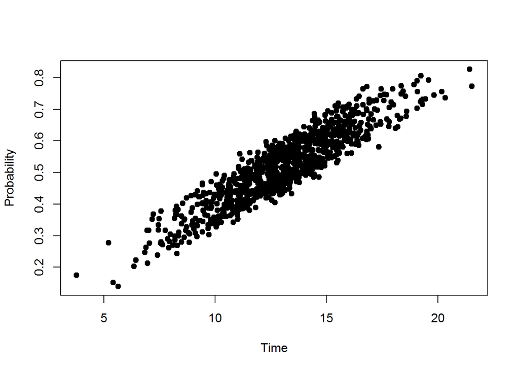

```r
plot(MarketingData$Time,MarketingData$Probability, type="p",pch=19,xlab="Time",ylab="Probability")
```

## 1.2 Linear model

### 1.2.1 Probability as response time as predictor

Estimate linear model with one predictor `Time` using `lm()`.

```r
lmProbabilityTime<-lm(Probability~Time,data=MarketingData)
lmProbabilityTime$coefficients
```

```
## (Intercept)        Time
## 0.007165356 0.039232604
```

```r
summary(lmProbabilityTime)
```

```
##
## Call:
## lm(formula = Probability ~ Time, data = MarketingData)
##
## Residuals:
##       Min        1Q    Median        3Q       Max
## -0.107643 -0.038418 -0.001423  0.036755  0.116378
##
## Coefficients:
##              Estimate Std. Error t value Pr(>|t|)
## (Intercept) 0.0071654  0.0076371   0.938    0.348
## Time        0.0392326  0.0005758  68.142   <2e-16 ***
## ---
## Signif. codes:  0 '***' 0.001 '**' 0.01 '*' 0.05 '.' 0.1 ' ' 1
##
## Residual standard error: 0.04584 on 998 degrees of freedom
## Multiple R-squared:  0.8231, Adjusted R-squared:  0.8229
## F-statistic:  4643 on 1 and 998 DF,  p-value: < 2.2e-16
```

Analyze the residuals

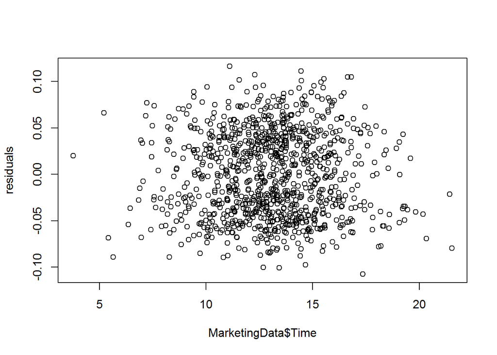

```r
residuals<-lmProbabilityTime$residuals
plot(MarketingData$Time,residuals)
```

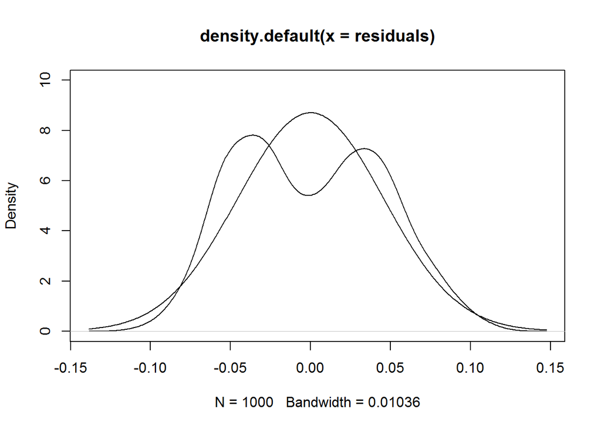

```r
density.Residuals<-density(residuals)
plot(density.Residuals,ylim=c(0,10))
lines(density.Residuals$x,dnorm(density.Residuals$x,mean=mean(residuals),sd=sd(residuals)))
```

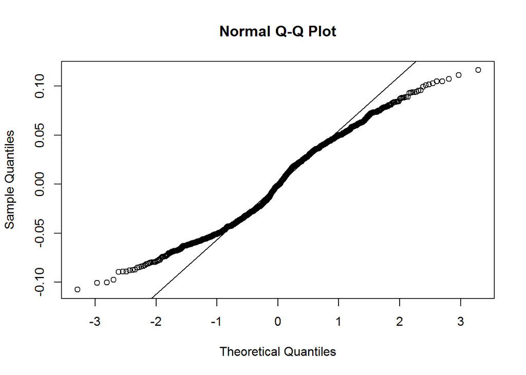

```r
qqnorm(residuals)
qqline(residuals)
```

**What do you conclude from the analysis of residuals?**

### 1.2.2 Probability as response, time and gender as predictors

Add fixed effects based on gender.  
Compare the two summaries.

```r
lmProbabilityTimeGender<-lm(Probability~Time+Gender,data=MarketingData)
summary(lmProbabilityTimeGender)
```

```
##
## Call:
## lm(formula = Probability ~ Time + Gender, data = MarketingData)
##
## Residuals:
##       Min        1Q    Median        3Q       Max
## -0.074464 -0.017687 -0.001208  0.015808  0.076044
##
## Coefficients:
##               Estimate Std. Error t value Pr(>|t|)
## (Intercept)  0.0409007  0.0042002   9.738   <2e-16 ***
## Time         0.0398264  0.0003126 127.408   <2e-16 ***
## GenderM     -0.0772236  0.0015783 -48.927   <2e-16 ***
## ---
## Signif. codes:  0 '***' 0.001 '**' 0.01 '*' 0.05 '.' 0.1 ' ' 1
##
## Residual standard error: 0.02487 on 997 degrees of freedom
## Multiple R-squared:  0.948,  Adjusted R-squared:  0.9479
## F-statistic:  9085 on 2 and 997 DF,  p-value: < 2.2e-16
```

```r
summary(lmProbabilityTime)
```

```
##
## Call:
## lm(formula = Probability ~ Time, data = MarketingData)
##
## Residuals:
##       Min        1Q    Median        3Q       Max
## -0.107643 -0.038418 -0.001423  0.036755  0.116378
##
## Coefficients:
##              Estimate Std. Error t value Pr(>|t|)
## (Intercept) 0.0071654  0.0076371   0.938    0.348
## Time        0.0392326  0.0005758  68.142   <2e-16 ***
## ---
## Signif. codes:  0 '***' 0.001 '**' 0.01 '*' 0.05 '.' 0.1 ' ' 1
##
## Residual standard error: 0.04584 on 998 degrees of freedom
## Multiple R-squared:  0.8231, Adjusted R-squared:  0.8229
## F-statistic:  4643 on 1 and 998 DF,  p-value: < 2.2e-16
```

**Interpret coefficient `GenderM`**.

### 1.2.3 Time as response, gender as predictor

```r
lmTimeGender<-lm(Time~Gender,data=MarketingData)
summary(lmTimeGender)
```

```
##
## Call:
## lm(formula = Time ~ Gender, data = MarketingData)
##
## Residuals:
##     Min      1Q  Median      3Q     Max
## -9.1488 -1.6594  0.0385  1.6463  8.4192
##
## Coefficients:
##             Estimate Std. Error t value Pr(>|t|)
## (Intercept)  12.9182     0.1170 110.377   <2e-16 ***
## GenderM       0.1960     0.1597   1.228     0.22
## ---
## Signif. codes:  0 '***' 0.001 '**' 0.01 '*' 0.05 '.' 0.1 ' ' 1
##
## Residual standard error: 2.518 on 998 degrees of freedom
## Multiple R-squared:  0.001508,   Adjusted R-squared:  0.0005071
## F-statistic: 1.507 on 1 and 998 DF,  p-value: 0.2199
```

```r
unique(predict(lmTimeGender))
```

```
## [1] 13.11425 12.91820
```

Extract group means, call them `FixedEffects`

```r
Manual<-aggregate(MarketingData$Time,
                         by=list(MarketingData$Gender),
                         function(z) mean(z))$x
(Manual<-Manual-mean(Manual))
```

```
## [1] -0.09802489  0.09802489
```

```r
fixedEffects<-c(lmTimeGender$coefficients[1],sum(lmTimeGender$coefficients))
(fixedEffects<-fixedEffects-mean(fixedEffects))
```

```
## (Intercept)
## -0.09802489  0.09802489
```

```r
cbind(Manual,fixedEffects)
```

```
##                  Manual fixedEffects
## (Intercept) -0.09802489  -0.09802489
##              0.09802489   0.09802489
```

## 1.3 Random effects

Learn how to fit the model using `lmer()` from library `lme4`

### 1.3.1 Time as response, gender as predictor

First, use the simplest random effects model with Time as output and Gender as random effect.

```r
suppressWarnings(library(lme4))
```

```r
lmerTimeGender<-lmer(Time~1+(1|Gender),data=MarketingData)
summary(lmerTimeGender)
```

```
## Linear mixed model fit by REML ['lmerMod']
## Formula: Time ~ 1 + (1 | Gender)
##    Data: MarketingData
##
## REML criterion at convergence: 4687.7
##
## Scaled residuals:
##     Min      1Q  Median      3Q     Max
## -3.6606 -0.6568  0.0249  0.6506  3.3671
##
## Random effects:
##  Groups   Name        Variance Std.Dev.
##  Gender   (Intercept) 0.006464 0.0804
##  Residual             6.341992 2.5183
## Number of obs: 1000, groups:  Gender, 2
##
## Fixed effects:
##             Estimate Std. Error t value
## (Intercept) 13.02104    0.09791     133
```

**What is the meaning of group random effect parameter `Gender`**?

Extract random effects.

```r
suppressWarnings(library(lattice))
```

Extract random effects.

```r
(randomEffects<-ranef(lmerTimeGender,condVar=T))
```

```
## $Gender
##   (Intercept)
## F -0.03297089
## M  0.03297089
##
## with conditional variances for "Gender"
```

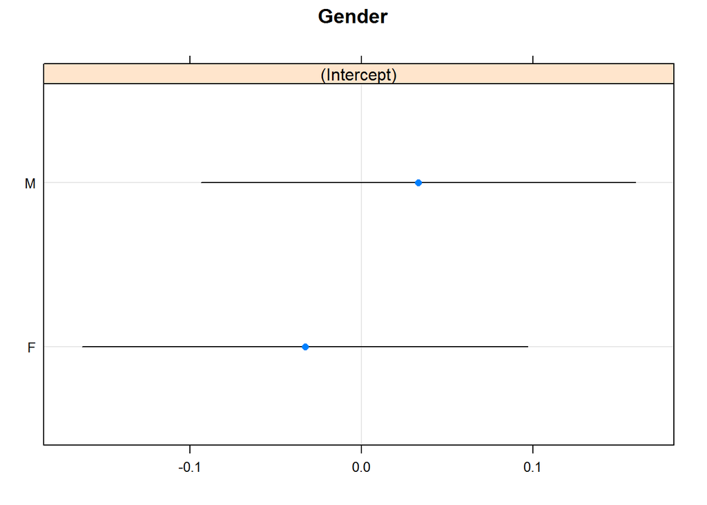

```r
dotplot(randomEffects)
```

Check the meaning of random effects: deviations of random gender means from the base level.

```r
summary(lmerTimeGender)$coefficients
```

```
##             Estimate Std. Error  t value
## (Intercept) 13.02104 0.09790661 132.9945
```

```r
baseLevel<-summary(lmerTimeGender)$coefficients[1]
pred<-unique(predict(lmerTimeGender))
pred<-sort(pred)
cbind(Manual=pred-baseLevel,
      RandomEffects=randomEffects$Gender)
```

```
##        Manual (Intercept)
## F -0.03297089 -0.03297089
## M  0.03297089  0.03297089
```

Variance-correlation matrix returns standard deviations.

```r
suppressWarnings(library(arm))
```

```r
VarCorr(lmerTimeGender)
```

```
##  Groups   Name        Std.Dev.
##  Gender   (Intercept) 0.080399
##  Residual             2.518331
```

```r
sqrt(sum(se.ranef(lmerTimeGender)$Gender^2)/2+var(randomEffects$Gender))
```

```
##             (Intercept)
## (Intercept)  0.08036591
```

```r
sd(residuals(lmerTimeGender))
```

```
## [1] 2.517907
```

One way of thinking about the variances returned by the summary of `lmer()` is: residual variance is the variance within the groups and each random effect variance is the variance between the groups.

Compare standard deviation of random effects with standard deviation of fixed effects to measure shrinkage.

```r
(sdFixed<-sd(fixedEffects))
```

```
## [1] 0.1386281
```

```r
(sdRandom<-sd(unlist(randomEffects)))
```

```
## [1] 0.04662787
```

```r
sdRandom/sdFixed
```

```
## [1] 0.3363522
```

### 1.3.2 Conversion probability as response, time and gender as predictors

Now apply `lmer()` to fit the model for probability with one predictor Time and one random effect based on Gender

(Skipped Code)

Extract fixed effects and random effects from the corresponding models.

```r
#Fixed
(lmCoeff<-lmProbabilityTimeGender$coefficients)
```

```
## (Intercept)        Time     GenderM
##  0.04090073  0.03982643 -0.07722360
```

```r
fixedEffects<-c(lmCoeff[1],lmCoeff[1]+lmCoeff[3])
(fixedEffects<-fixedEffects-mean(fixedEffects))
```

```
## (Intercept) (Intercept)
##   0.0386118  -0.0386118
```

```r
(randomEffects<-unlist(ranef(lmerProbabilityTimeGender)$Gender))
```

```
## (Intercept)1 (Intercept)2
##   0.03859567  -0.03859567
```

Find coefficient of shrinkage as ratio of standard deviations.

```r
sd(randomEffects)/sd(fixedEffects)
```

```
## [1] 0.9995823
```

**Which model fits the data better**?

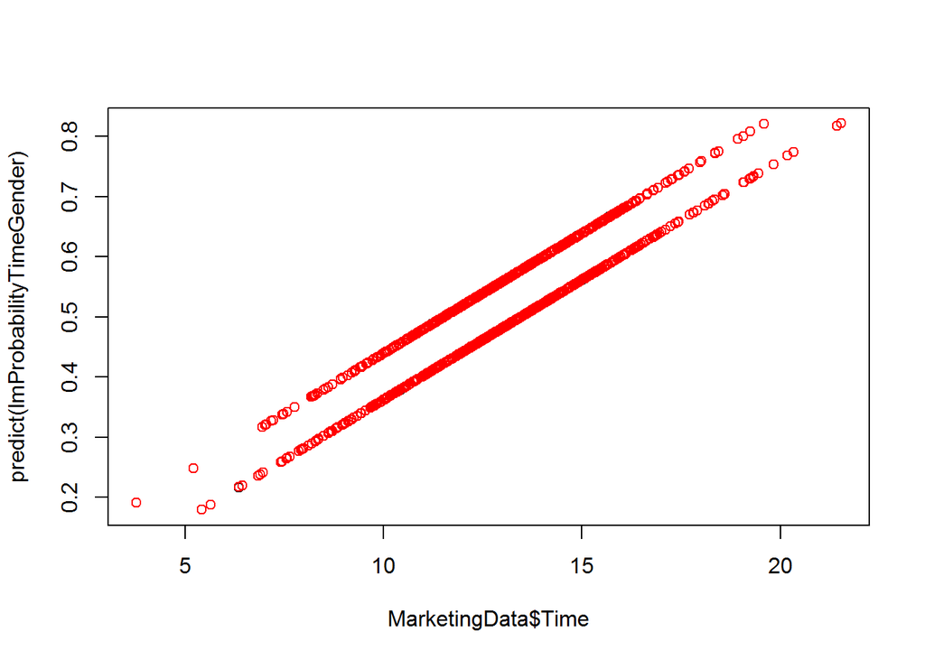

```r
plot(MarketingData$Time,predict(lmProbabilityTimeGender))
points(MarketingData$Time,predict(lmerProbabilityTimeGender),col="red")
```

```r
c(Fixed=AIC(lmProbabilityTimeGender),Random=AIC(lmerProbabilityTimeGender))
```

```
##     Fixed    Random
## -4545.422 -4509.874
```

# 2 Test

**Be careful using given 5 attempts to submit the test**. When a reset of 5 submissions is requested in order to receive additional 5 attempts, all previous scores are erased. In addition all new scores will be multiplied by 0.95, i.e. maximum score after reset is 95.

[interactive chart not shown]